# Exploring Springleaf Data

Read in the Data and remove ID and response variables

```r
train <- read_csv("D:/kaggle/Springleaf/DATA/CSV/train.csv")
test <- read_csv("D:/kaggle/Springleaf/DATA/CSV/test.csv")
dim(train); dim(test)
```

```
## [1] 145231   1934
```

```
## [1] 145232   1933
```

```r
response <- train$target

train_ID <- train$ID

test_ID <- test$ID
```

Modify train and test sets

```r
training <- subset(train, select = -c(ID, target))

testing <- subset(test, select = -c(ID))

dim(training); dim(testing)
```

```
## [1] 145231   1932
```

```
## [1] 145232   1932
```

CHECKING FOR DUPLICATE ROWS

```r
nrow(training) - nrow(unique(training)) #DONT RUN TAKES RIDICULOUSLY LONG TIME
```

```
## [1] 0
```

CHECKING FOR UNIQUE ELEMENTS IN A COLUMN

```r
col_unique <- sapply(training, function(x) unique(x))
```

CHECKING FOR NUMBER OF UNIQUE VALUES IN A COLUMN

```r
col_ele <- as.data.frame(lapply(training, function(x) length(unique(x))))

##GET THE COLUMN NAMES

length(col_ele)
```

```
## [1] 1932
```

CHECK FOR COLUMNS WITH 1,2,3 UNIQUE ELEMENTS

```r
length(col_ele[col_ele == seq(1,3,1)])
```

```
## [1] 38
```

```r
length(col_ele[col_ele == 1])
```

```
## [1] 7
```

```r
length(col_ele[col_ele == 2]) #MOSTLY COLUMNS WITH DUMMY VARS
```

```
## [1] 65
```

```r
length(col_ele[col_ele == 3])
```

```
## [1] 36
```

CHECK COLUMNS WITH ONLY 1 UNIQUE VALUE

```r
unique_one <- subset(col_ele , select = c(col_ele == 1))

unique_oneDF <- training[, c(names(unique_one))]

head(unique_oneDF)
```

```
##   VAR_0205 VAR_0207 VAR_0213 VAR_0214 VAR_0840 VAR_0847 VAR_1428
## 1       NA       NA       NA       NA       NA        1        0
## 2       NA       NA       NA       NA       NA        1        0
## 3       NA       NA       NA       NA       NA        1        0
## 4       NA       NA       NA       NA       NA        1        0
## 5       NA       NA       NA       NA       NA        1        0
## 6       NA       NA       NA       NA       NA        1        0
```

IDENTIFY AND SEPERATE NUMERIC AND NON NUMERIC COLUMNS

```r
training_num <- training[, sapply(training, is.numeric)] #CHECK WHETHER LAPPLY WORKS

training_char <- training[,sapply(training, is.character)]

cat("Number of Numerical columns :" , dim(training_num)[2], "|Number of character columns :", dim(training_char)[2])
```

```
## Number of Numerical columns : 1877 |Number of character columns : 50
```

LOOK INTO NUMERIC COLUMNS DF

CHECK FOR UNIQUE AND LENGTH OF UNIQUE COLUMNS

```r
str(lapply(training_num, unique))
```

```
## List of 1877
##  $ VAR_0002: int [1:820] 224 7 116 240 72 4 60 13 17 24 ...
##  $ VAR_0003: int [1:588] 0 53 3 300 261 4 132 75 16 72 ...
##  $ VAR_0004: int [1:7935] 4300 4448 3464 3200 2000 4422 40000 3600 2296 450 ...
##  $ VAR_0006: int [1:38] 0 1 6 2 3 4 7 5 13 8 ...
##  $ VAR_0007: int [1:36] 0 1 2 6 3 5 9 4 7 66 ...
##  $ VAR_0013: int [1:38] 0 1 6 2 3 4 7 5 13 8 ...
##  $ VAR_0014: int [1:38] 0 1 2 6 3 4 5 7 67 9 ...
##  $ VAR_0015: int [1:27] 0 1 4 2 3 7 10 5 6 8 ...
##  $ VAR_0016: int [1:30] 1 2 7 3 6 9 5 4 11 0 ...
##  $ VAR_0017: int [1:26] 0 1 6 2 7 4 3 5 10 11 ...
##  $ VAR_0018: int [1:2] 0 NA
##  $ VAR_0019: int [1:2] 0 NA
##  $ VAR_0020: int [1:2] 0 NA
##  $ VAR_0021: int [1:2] 0 NA
```

[output cut: 86 more lines]

```r
str(lapply(training_num, function(x) length(unique(x))))
```

```
## List of 1877
##  $ VAR_0002: int 820
##  $ VAR_0003: int 588
##  $ VAR_0004: int 7935
##  $ VAR_0006: int 38
##  $ VAR_0007: int 36
##  $ VAR_0013: int 38
##  $ VAR_0014: int 38
##  $ VAR_0015: int 27
##  $ VAR_0016: int 30
##  $ VAR_0017: int 26
##  $ VAR_0018: int 2
##  $ VAR_0019: int 2
##  $ VAR_0020: int 2
##  $ VAR_0021: int 2
```

[output cut: 86 more lines]

```r
numeric_ele <- (lapply(training_num, function(x) length(unique(x))))

#CHECK FOR COLUMNS WITH 1,2,3 UNIQUE ELEMENTS

length(numeric_ele[numeric_ele == 1])
```

```
## [1] 2
```

```r
length(numeric_ele[numeric_ele == 2]) #MOSTLY COLUMNS WITH DUMMY VARS
```

```
## [1] 52
```

```r
length(numeric_ele[numeric_ele == 3])
```

```
## [1] 30
```

```r
#CHECK COLUMNS WITH ONLY 1 UNIQUE VALUE

numeric_one <- subset(numeric_ele , subset  = c(numeric_ele == 1))

numeric_oneDF <- training_num[, c(names(numeric_one))]

#CHECK ELEMENTS

lapply(numeric_oneDF, table)
```

```
## $VAR_0847
##
##      1
## 145231
##
## $VAR_1428
##
##      0
## 145231
```

```r
#CHECK COLUMNS WITH 2 UNIQUE VALUES

numeric_two <- subset(numeric_ele , subset = c(numeric_ele == 2))

numeric_twoDF <- training_num[, c(names(numeric_two))]

#CHECK ELEMENTS

lapply(numeric_twoDF, table)
```

```
## $VAR_0018
##
##      0
## 145175
##
## $VAR_0019
##
##      0
## 145175
##
## $VAR_0020
##
##      0
## 145175
##
## $VAR_0021
##
##      0
## 145175
##
## $VAR_0022
##
##      0
## 145175
##
## $VAR_0023
##
##      0
## 145175
##
## $VAR_0024
##
##      0
## 145175
##
## $VAR_0025
##
##      0
## 145175
##
```

[output cut: 204 more lines]

```
##
## $VAR_1164
##
##      0      1
## 144409    822
##
## $VAR_1165
##
##      0      1
## 144165   1066
##
## $VAR_1427
##
##      0      1
## 145145     86
```

LOOK INTO CHARACTER COLUMNS DF

```r
str(lapply(training_char, unique), vec.len =4 )
```

```
## List of 50
##  $ VAR_0001: chr [1:3] "H" "R" "Q"
##  $ VAR_0005: chr [1:4] "C" "B" "N" "S"
##  $ VAR_0008: chr [1:2] "false" ""
##  $ VAR_0009: chr [1:2] "false" ""
##  $ VAR_0010: chr [1:2] "false" ""
##  $ VAR_0011: chr [1:2] "false" ""
##  $ VAR_0012: chr [1:2] "false" ""
##  $ VAR_0043: chr [1:2] "false" ""
##  $ VAR_0044: chr [1:2] "[]" ""
##  $ VAR_0073: chr [1:1459] "" "04SEP12:00:00:00" "26JAN12:00:00:00" "18SEP12:00:00:00" ...
##  $ VAR_0075: chr [1:2372] "08NOV11:00:00:00" "10NOV11:00:00:00" "13DEC11:00:00:00" "23SEP10:00:00:00" ...
##  $ VAR_0156: chr [1:731] "" "14JUL11:00:00:00" "21NOV11:00:00:00" "13APR12:00:00:00" ...
##  $ VAR_0157: chr [1:425] "" "05JUL12:00:00:00" "05JUN11:00:00:00" "26MAY12:00:00:00" ...
##  $ VAR_0158: chr [1:408] "" "31JAN12:00:00:00" "01MAR12:00:00:00" "02JAN12:00:00:00" ...
```

[output cut: 36 more lines]

```r
char_ele <- (lapply(training_char, function(x) length(unique(x))))

#CHECK FOR COLUMNS WITH 1,2,3 UNIQUE ELEMENTS

range(char_ele)
```

```
## [1]     2 12387
```

```r
length(char_ele[char_ele == 1])
```

```
## [1] 0
```

```r
length(char_ele[char_ele == 2])
```

```
## [1] 13
```

```r
length(char_ele[char_ele == 3])
```

```
## [1] 6
```

SOME COLUMNS HAVE NAMES: FIRST SEPERATE DATES THEN LOOK INTO THEM

SEPERATE OUT DATES AND TIMES INTO DIFFERENT DFS

```r
training_date <- training_char[, grep("JAN1|FEB1|MAR1", training_char)]

names(training_date)
```

```
##  [1] "VAR_0073" "VAR_0075" "VAR_0156" "VAR_0157" "VAR_0158" "VAR_0159"
##  [7] "VAR_0166" "VAR_0167" "VAR_0168" "VAR_0169" "VAR_0176" "VAR_0177"
## [13] "VAR_0178" "VAR_0179" "VAR_0204" "VAR_0217"
```

```r
#REMOVE DATES FROM char DF

training_charD <- training_char[, !(names(training_char) %in% names(training_date))]

#training_charD has only CHAR variables checking further

str(lapply(training_charD, unique), vec.len =4 )
```

```
## List of 34
##  $ VAR_0001: chr [1:3] "H" "R" "Q"
##  $ VAR_0005: chr [1:4] "C" "B" "N" "S"
##  $ VAR_0008: chr [1:2] "false" ""
##  $ VAR_0009: chr [1:2] "false" ""
##  $ VAR_0010: chr [1:2] "false" ""
##  $ VAR_0011: chr [1:2] "false" ""
##  $ VAR_0012: chr [1:2] "false" ""
##  $ VAR_0043: chr [1:2] "false" ""
##  $ VAR_0044: chr [1:2] "[]" ""
##  $ VAR_0196: chr [1:2] "false" ""
##  $ VAR_0200: chr [1:12387] "FT LAUDERDALE" "SANTEE" "REEDSVILLE" "LIBERTY" ...
##  $ VAR_0202: chr [1:2] "BatchInquiry" ""
##  $ VAR_0216: chr [1:2] "DS" ""
##  $ VAR_0222: chr [1:2] "C6" ""
```

[output cut: 20 more lines]

SEPERATE FIELDS WITH BINARY VALUES

```r
charD_ele <- (lapply(training_charD, function(x) length(unique(x))))

charD_two <- subset(charD_ele, subset = c(charD_ele == 2))

names(charD_two)
```

```
##  [1] "VAR_0008" "VAR_0009" "VAR_0010" "VAR_0011" "VAR_0012" "VAR_0043"
##  [7] "VAR_0044" "VAR_0196" "VAR_0202" "VAR_0216" "VAR_0222" "VAR_0229"
## [13] "VAR_0239"
```

```r
charD_twoDF <- training_char[, c(names(charD_two))]

#CHECK ELEMENTS OF DF

lapply(charD_twoDF, table)
```

```
## $VAR_0008
##
##         false
##     56 145175
##
## $VAR_0009
##
##         false
##     56 145175
##
## $VAR_0010
##
##         false
##     56 145175
##
## $VAR_0011
##
##         false
##     56 145175
##
## $VAR_0012
##
##         false
##     56 145175
##
## $VAR_0043
##
##         false
##     56 145175
##
## $VAR_0044
##
##            []
##     56 145175
##
## $VAR_0196
##
##         false
##     56 145175
##
```

[output cut: 9 more lines]

```
##
## $VAR_0222
##
##            C6
##     56 145175
##
## $VAR_0229
##
##         false
##     56 145175
##
## $VAR_0239
##
##         false
##     56 145175
```

DRILL DOWN FURTHER BY REMOVING THESE COLS

```r
training_charD_edit <- training_charD[, !(names(training_charD) %in% names(charD_two))]

#training_charD_edit has only CHAR variables checking further

str(lapply(training_charD_edit, unique), vec.len = 4)
```

```
## List of 21
##  $ VAR_0001: chr [1:3] "H" "R" "Q"
##  $ VAR_0005: chr [1:4] "C" "B" "N" "S"
##  $ VAR_0200: chr [1:12387] "FT LAUDERDALE" "SANTEE" "REEDSVILLE" "LIBERTY" ...
##  $ VAR_0226: chr [1:3] "false" "true" ""
##  $ VAR_0230: chr [1:3] "false" "true" ""
##  $ VAR_0232: chr [1:3] "true" "false" ""
##  $ VAR_0236: chr [1:3] "true" "false" ""
##  $ VAR_0237: chr [1:46] "FL" "CA" "WV" "TX" ...
##  $ VAR_0274: chr [1:58] "FL" "MI" "WV" "TX" ...
##  $ VAR_0283: chr [1:8] "S" "H" "-1" "P" ...
##  $ VAR_0305: chr [1:9] "S" "P" "H" "-1" ...
##  $ VAR_0325: chr [1:10] "-1" "H" "R" "S" ...
##  $ VAR_0342: chr [1:51] "CF" "EC" "UU" "-1" ...
##  $ VAR_0352: chr [1:5] "O" "R" "U" "-1" ...
##  $ VAR_0353: chr [1:5] "U" "R" "O" "-1" ...
##  $ VAR_0354: chr [1:5] "O" "R" "-1" "U" ...
##  $ VAR_0404: chr [1:1824] "CHIEF EXECUTIVE OFFICER" "-1" "CONTA" "CONTACT" ...
##  $ VAR_0466: chr [1:3] "-1" "I" ""
##  $ VAR_0467: chr [1:5] "-1" "Discharged" "Dismissed" "" ...
##  $ VAR_0493: chr [1:609] "COMMUNITY ASSOCIATION MANAGER" "-1" "LICENSED PRACTICAL NURSE" "LICENSED VOCATIONAL NURSE" ...
##  $ VAR_1934: chr [1:5] "IAPS" "RCC" "BRANCH" "MOBILE" ...
```

```r
#FURTHER DRILL DOWN BY SEPERATING NAMES

charD_many <- subset(charD_ele, subset = c(charD_ele == 1824 |
                                             charD_ele == 609 | charD_ele == 12387))
names(charD_many)
```

```
## [1] "VAR_0200" "VAR_0404" "VAR_0493"
```

```r
##PLACE EACH OF THE NAMES IN A INDI.. DF AND CHECK IT OUT

charDF <- data.frame(cities = training_charD_edit$VAR_0200)

dim(charDF)
```

```
## [1] 145231      1
```

```r
head(charDF)
```

```
##          cities
## 1 FT LAUDERDALE
## 2        SANTEE
## 3    REEDSVILLE
## 4       LIBERTY
## 5     FRANKFORT
## 6        SPRING
```

```r
nrow(na.omit(charDF))
```

```
## [1] 145231
```

```r
charDF1 <- data.frame(small_work = training_charD_edit$VAR_0404)

length(charDF1[charDF1 != -1])
```

```
## [1] 14788
```

```r
##REMOVING NA`S FROM CHARDF1

no_NA1 <- charDF1[charDF1 != -1]

no_NA1 <- no_NA1[no_NA1 != ""]

no_NA1 <- no_NA1[no_NA1 != "CONTACT"]

no_NA1 <- no_NA1[no_NA1 != "CONTA"]

NA1 <- (as.data.frame(table(no_NA1)))

charDF2 <- data.frame(big_work = training_charD_edit$VAR_0493)

length(charDF2[charDF2 != -1])
```

```
## [1] 10049
```

```r
nrow(charDF2) - length(charDF2[charDF2 != -1])
```

```
## [1] 135182
```

```r
no_NA2 <- charDF2[charDF2 != -1]

no_NA2 <- no_NA2[no_NA2 != ""]

NA2 <- (as.data.frame(table(no_NA2)))

NA1
```

```
##                                    no_NA1 Freq
## 1                              # 2 MEMBER    1
## 2              2007 - 2008 CHAPTER MEMBER    1
## 3                                    3583    1
## 4                                       A    1
## 5         A AND R RESEARCH REPRESENTATIVE    1
## 6                        ACADEMIC ADVISOR    1
## 7                         ACCESS CONTROLS    1
## 8              ACCESS TO CLUBHOUSE MEMBER    1
## 9                     ACCOUNT COORDINATOR    1
## 10                       ACCOUNT DIRECTOR    1
## 11                      ACCOUNT EXECUTIVE    7
## 12                        ACCOUNT MANAGER    3
## 13                             ACCOUNTANT    5
## 14                             ACCOUNTING    1
```

[output cut: 1806 more lines]

```r
NA2
```

```
##                                                           no_NA2 Freq
## 1                                                     ACCOUNTANT   18
## 2                              ACTIVE ASSOCIATES WITH NO PRIVACY    1
## 3                                                    ACTIVE CPAS    1
## 4                                                  ACUPUNCTURIST    2
## 5                                        ADMINISTRATOR/ASSISTANT    2
## 6                                         ADVANCED PRACTICE - NP    1
## 7                             ADVANCED PRACTICE REGISTERED NURSE    1
## 8                                                  ADVISOR AGENT    3
## 9                                                   AESTHETICIAN    2
## 10                                       AGENCY EMPLOYEE - ARMED    1
## 11                                                AGENCY MANAGER    1
## 12                                                         AGENT    4
## 13                                AIR CONDITIONING/REFRIGERATION    2
## 14                                        ALCOHOL/DRUG COUNSELOR    1
```

[output cut: 593 more lines]

DRILL DOWN INTO DATES VALUES

```r
names(training_date)
```

```
##  [1] "VAR_0073" "VAR_0075" "VAR_0156" "VAR_0157" "VAR_0158" "VAR_0159"
##  [7] "VAR_0166" "VAR_0167" "VAR_0168" "VAR_0169" "VAR_0176" "VAR_0177"
## [13] "VAR_0178" "VAR_0179" "VAR_0204" "VAR_0217"
```

```r
training_date <- sapply(training_date, function(x) strptime(x, "%d%B%y :%H:%M:%S"))

training_date = do.call(cbind.data.frame, training_date)

head(training_date)
```

```
##     VAR_0073   VAR_0075 VAR_0156 VAR_0157 VAR_0158 VAR_0159 VAR_0166
## 1       <NA> 2011-11-08     <NA>     <NA>     <NA>     <NA>     <NA>
## 2 2012-09-04 2011-11-10     <NA>     <NA>     <NA>     <NA>     <NA>
## 3       <NA> 2011-12-13     <NA>     <NA>     <NA>     <NA>     <NA>
## 4       <NA> 2010-09-23     <NA>     <NA>     <NA>     <NA>     <NA>
## 5       <NA> 2011-10-15     <NA>     <NA>     <NA>     <NA>     <NA>
## 6       <NA> 2012-06-06     <NA>     <NA>     <NA>     <NA>     <NA>
##   VAR_0167 VAR_0168 VAR_0169 VAR_0176 VAR_0177 VAR_0178 VAR_0179
## 1     <NA>     <NA>     <NA>     <NA>     <NA>     <NA>     <NA>
## 2     <NA>     <NA>     <NA>     <NA>     <NA>     <NA>     <NA>
## 3     <NA>     <NA>     <NA>     <NA>     <NA>     <NA>     <NA>
## 4     <NA>     <NA>     <NA>     <NA>     <NA>     <NA>     <NA>
## 5     <NA>     <NA>     <NA>     <NA>     <NA>     <NA>     <NA>
## 6     <NA>     <NA>     <NA>     <NA>     <NA>     <NA>     <NA>
##              VAR_0204            VAR_0217
## 1 2014-01-29 21:16:00 2011-11-08 02:00:00
## 2 2014-02-01 00:11:00 2012-10-02 02:00:00
## 3 2014-01-30 15:11:00 2011-12-13 02:00:00
## 4 2014-02-01 00:07:00 2012-11-01 02:00:00
## 5 2014-01-29 19:31:00 2011-10-15 02:00:00
## 6 2014-01-30 23:52:00 2012-06-06 02:00:00
```

```r
##DRILL DOWN TIME VALUES

training_time <- training_date[, names(training_date) %in% c("VAR_0204","VAR_0217")]

training_time <- data.frame(sapply(training_time, function(x) strftime(x, "%H:%M:%S")))

dim(training_time); head(training_time)
```

```
## [1] 145231      2
```

```
##   VAR_0204 VAR_0217
## 1 21:16:00 02:00:00
## 2 00:11:00 02:00:00
## 3 15:11:00 02:00:00
## 4 00:07:00 02:00:00
## 5 19:31:00 02:00:00
## 6 23:52:00 02:00:00
```

```r
training_hour <- as.data.frame(sapply(training_time, function(x)
as.numeric(as.character(substr(x, 1,2)))))

dim(training_hour); head(training_hour)
```

```
## [1] 145231      2
```

```
##   VAR_0204 VAR_0217
## 1       21        2
## 2        0        2
## 3       15        2
## 4        0        2
## 5       19        2
## 6       23        2
```

```r
training_minute <- as.data.frame(sapply(training_time, function(x)

  as.numeric(as.character(substr(x, 4,5)))))

dim(training_minute); head(training_minute)
```

```
## [1] 145231      2
```

```
##   VAR_0204 VAR_0217
## 1       16        0
## 2       11        0
## 3       11        0
## 4        7        0
## 5       31        0
## 6       52        0
```

HISTOGRAM OF DATES

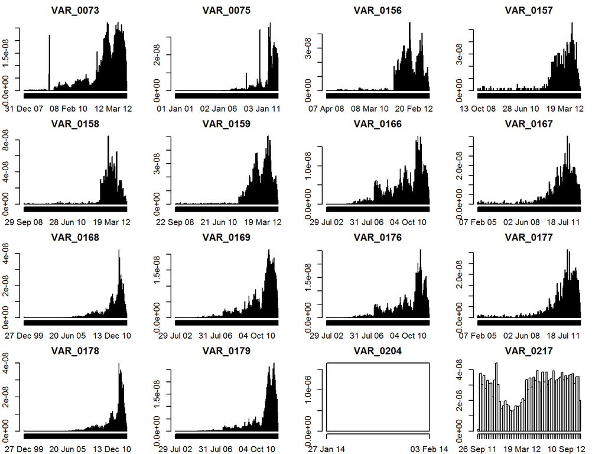

```r
par(mar=c(2,2,2,2),mfrow=c(4,4))

for(i in 1:16) hist(training_date[,i], "weeks", format = "%d %b %y", main =
                      colnames(training_date)[i], xlab="", ylab="")
```

HISTOGRAM OF TIMES

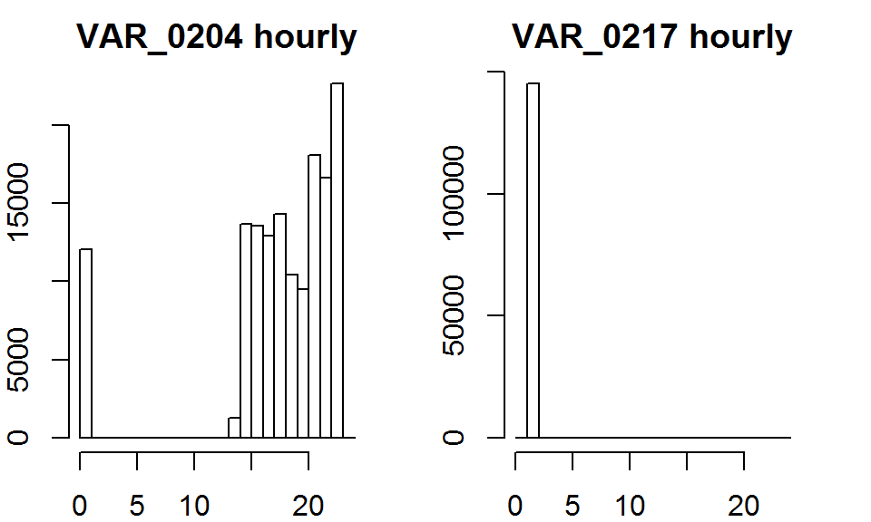

```r
par(mar=c(2,2,2,2),mfrow=c(1,2))

for(i in 1:2) hist(training_hour[,i], main = paste(colnames(training_hour)[i], "hourly"),
                   breaks = c(0:24), xlab="", ylab="")
```

TAKING A LOOK AT THE GEOGRAPHICAL BREAKDOWN OF STATE FEATURES

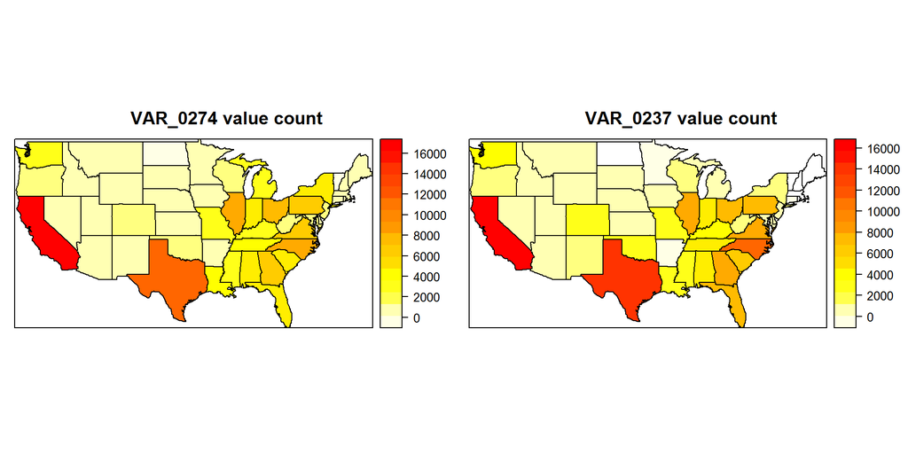

```r
mapUSA <- map('state', fill=TRUE, plot=FALSE)

nms <- sapply(strsplit(mapUSA$names,  ':'),  function(x)x[1])

USApolygons <- map2SpatialPolygons(mapUSA,  IDs = nms,  CRS('+proj=longlat'))

mapStates = function(df, feat){

    dat = data.frame(table(df[,feat]))

    names(dat) = c("state.abb", "value")

    dat$states <- tolower(state.name[match(dat$state.abb,  state.abb)])

  idx <- match(unique(nms),  dat$states)

  dat2 <- data.frame(value = dat$value[idx], state = unique(nms))

  row.names(dat2) <- unique(nms)

  USAsp <- SpatialPolygonsDataFrame(USApolygons,  data = dat2)

  spplot(USAsp['value'], main=paste(feat, "value count"),
         col.regions=rev(heat.colors(21)))
}

grid.arrange(mapStates(training_char, "VAR_0274"), mapStates(training_char, "VAR_0237"),ncol=2)
```

NUMBER OF UNIQUE VALUES PER COLUMN

```r
num_unique = sapply(training_num, function(x) length(unique(x)))

char_unique = sapply(training_char, function(x) length(unique(x)))

date_unique = sapply(training_date, function(x) length(unique(x)))

all_unique = rbind(data.frame(count=num_unique, type="Numerical"),

                   data.frame(count=char_unique, type="Character"),

                   data.frame(count=date_unique, type="Date"))
```

PLOT OF NUMBER OF UNIQUE VALUES PER COLUMN

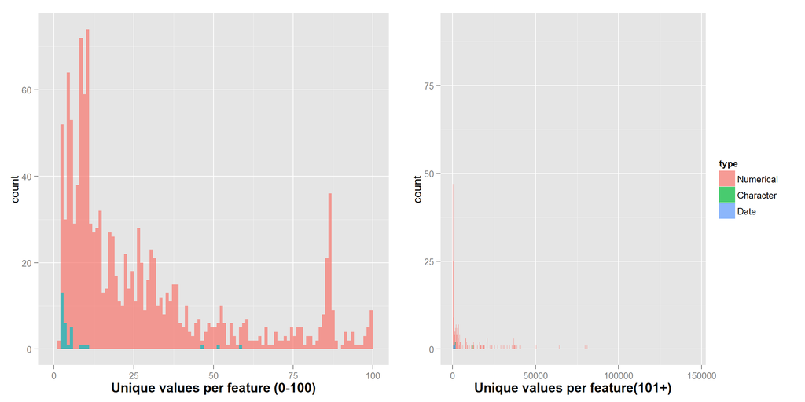

```r
g1 = ggplot(all_unique, aes(x = count, fill=type)) +

  geom_histogram(binwidth = 1, alpha=0.7, position="identity") +

  xlab("Unique values per feature (0-100)")+ theme(legend.position = "none") +

  xlim(c(0,100)) +theme(axis.title.x=element_text(size=14,face="bold"))

g2 = ggplot(all_unique, aes(x = count, fill=type)) +

  geom_histogram(binwidth = 100, alpha=0.7, position="identity") +

  xlab("Unique values per feature(101+)")  + xlim(c(101,nrow(train))) +

  theme(axis.title.x=element_text(size=14, face="bold"))

grid.arrange(g1, g2, ncol=2)
```

LOOKING AT THE NUMBER OF NA`s per feature type

```r
num_na = sapply(training_num, function(x) sum(is.na(x)))

str(lapply(training_num, function(x) sum(is.na(x))))
```

```
## List of 1877
##  $ VAR_0002: int 0
##  $ VAR_0003: int 0
##  $ VAR_0004: int 0
##  $ VAR_0006: int 56
##  $ VAR_0007: int 56
##  $ VAR_0013: int 56
##  $ VAR_0014: int 56
##  $ VAR_0015: int 56
##  $ VAR_0016: int 56
##  $ VAR_0017: int 56
##  $ VAR_0018: int 56
##  $ VAR_0019: int 56
##  $ VAR_0020: int 56
##  $ VAR_0021: int 56
```

[output cut: 86 more lines]

```r
char_na = sapply(training_char, function(x) sum(is.na(x)))

str(lapply(training_char, function(x) sum(is.na(x))))
```

```
## List of 50
##  $ VAR_0001: int 0
##  $ VAR_0005: int 0
##  $ VAR_0008: int 0
##  $ VAR_0009: int 0
##  $ VAR_0010: int 0
##  $ VAR_0011: int 0
##  $ VAR_0012: int 0
##  $ VAR_0043: int 0
##  $ VAR_0044: int 0
##  $ VAR_0073: int 0
##  $ VAR_0075: int 0
##  $ VAR_0156: int 0
##  $ VAR_0157: int 0
##  $ VAR_0158: int 0
```

[output cut: 36 more lines]

```r
date_na = sapply(training_date, function(x) sum(is.na(x)))

str(lapply(training_date, function(x) sum(is.na(x))))
```

```
## List of 16
##  $ VAR_0073: int 101127
##  $ VAR_0075: int 56
##  $ VAR_0156: int 139361
##  $ VAR_0157: int 144311
##  $ VAR_0158: int 143142
##  $ VAR_0159: int 139361
##  $ VAR_0166: int 131001
##  $ VAR_0167: int 142664
##  $ VAR_0168: int 134506
##  $ VAR_0169: int 131001
##  $ VAR_0176: int 127699
##  $ VAR_0177: int 141873
##  $ VAR_0178: int 133158
##  $ VAR_0179: int 127699
##  $ VAR_0204: int 56
##  $ VAR_0217: int 56
```

```r
all_na = rbind(data.frame(count=num_na, type="Numerical"),

               data.frame(count=char_na, type="Character"),

               data.frame(count=date_na, type="Date"))

all_na = data.frame(all_na)

all_na = all_na[all_na$count>0,]

head(all_na, 10)
```

```
##          count      type
## VAR_0006    56 Numerical
## VAR_0007    56 Numerical
## VAR_0013    56 Numerical
## VAR_0014    56 Numerical
## VAR_0015    56 Numerical
## VAR_0016    56 Numerical
## VAR_0017    56 Numerical
## VAR_0018    56 Numerical
## VAR_0019    56 Numerical
## VAR_0020    56 Numerical
```

PLOT OF NUMBER OF NA`s PER FEATURE TYPE

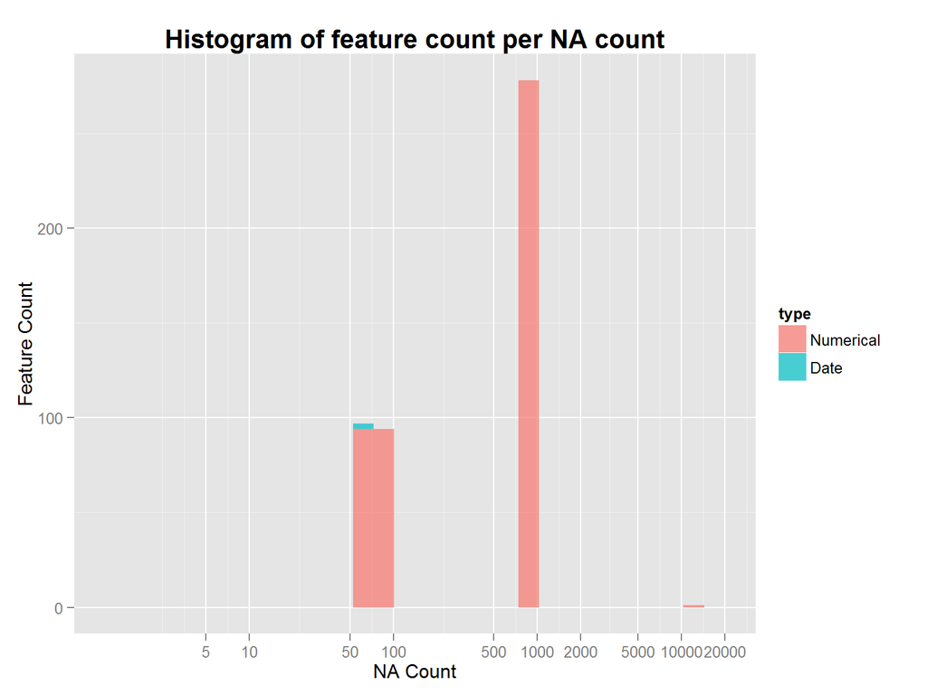

```r
breaks <- c(5,10,50,100,500,1000,2000)

ggplot(all_na, aes(x = count, fill=type)) +

  geom_histogram(alpha=0.7) +

  # scale_y_log10(limits=c(1,2000), breaks=breaks) +

  scale_x_log10(limits=c(1,20000), breaks=c(breaks,5000,10000,20000)) +

  labs(title="Histogram of feature count per NA count", size=24, face="bold") +

  theme(plot.title = element_text(size = 16, face = "bold")) +

  xlab("NA Count") + ylab("Feature Count")
```